# Running all models on Simulated Data

In the first part of our tutorial (testing our Stan models against the Mplus equivalents), we will work with simulated data for two main reasons: First, when using simulated data, the *generating parameter values* (sometimes denoted as *ground truth*) are known. Thereby we can check the recovery of the chosen set of parameters. Second, we are free to specify the characteristics of the data set (number of subjects, variables, measurement points, …). To keep this tutorial concise, we will stick to the most simple case and use bivariate data. Please refer to the paper (manuscript in prep) for reference on which parameters indicate what. Open the code block to see the code. *A great thanks go to my research assistant Valentin Pratz for setting up the simulations and help in Stan code.*

First, load the libraries and functions that will be needed later on:

```r
library(tidyverse)
library(MplusAutomation)
library(cmdstanr)
library(bayesplot)
library(RColorBrewer)
library(MASS)
library(igraph)
library(ggpubr)

source("source/rlkjcorr.R")
source("source/loadFunction.R")
LoadFunction(file="source/results.r", rhat_comp_F_MP, est_comp_F_MP)

set_cmdstan_path(file.path("C:/ProgramData/cmdstan-2.33.1")) # set local cmdstan location

# Parameters that are held constant across modeling of all 6 models
set.seed(123)
N_subj = 100
N_obs = 50
varsNames = c("X", "Y", "phi_X", "phi_Y", "phi_XY", "beta_YX", "psi_X", "psi_Y")

# Simulate the within-level structure of the Hamaker et al., 2023 book chapter models.
# Remains the same across all 6 models.
# Written by Valentin Pratz

simulate_within <- function(mu_X, mu_Y, phi_X, phi_Y, phi_XY, beta_YX, psi_X, psi_Y, N_obs) {
  X = rnorm(n=N_obs, 0, psi_X)
  Y = rnorm(n=N_obs, 0, psi_Y)
  for (t in 2:N_obs) {
    # iteratively add the regressive components
    Y[t] = Y[t] + phi_Y * Y[t-1] + phi_XY * X[t-1]
    X[t] = X[t] + phi_X * X[t-1] + beta_YX * Y[t]
  }
  # shift by individual mean
  X = X + mu_X
  Y = Y + mu_Y
  return(list(X=X,Y=Y))
}

# Function to check divergences in data simulations
data_summary_plot <- function(X,Y) {
  par(mfrow=c(2,1), mar=c(4,4,0,0))
  plot(1:N_obs, apply(X, 2, min), ylim = c(min(X),max(X)), type='b', xlab = "", "ylab" = "X")
  lines(1:N_obs, apply(X, 2, max), type='b')
  lines(1:N_obs, apply(X, 2, mean), type='b')
  plot(1:N_obs, apply(Y, 2, min), ylim = c(min(Y),max(Y)), type='b', xlab = "Time", "ylab" = "Y")
  lines(1:N_obs, apply(Y, 2, max), type='b')
  lines(1:N_obs, apply(Y, 2, mean), type='b')
}
```

```r
modelNr = 1
modelName = "hamaker model 1"
```

# 1 Model 1

## 1.1 Simulating data

For certain parameters, the time series might diverge. We can check graphically if that occurred. If a divergent time series is present, we would see exploding minimum or maximum values for later time steps. As this doesn’t occur in reality, it would indicate an invalid simulation. Here, the pattern looks reasonable, so we can use this simulated data set.

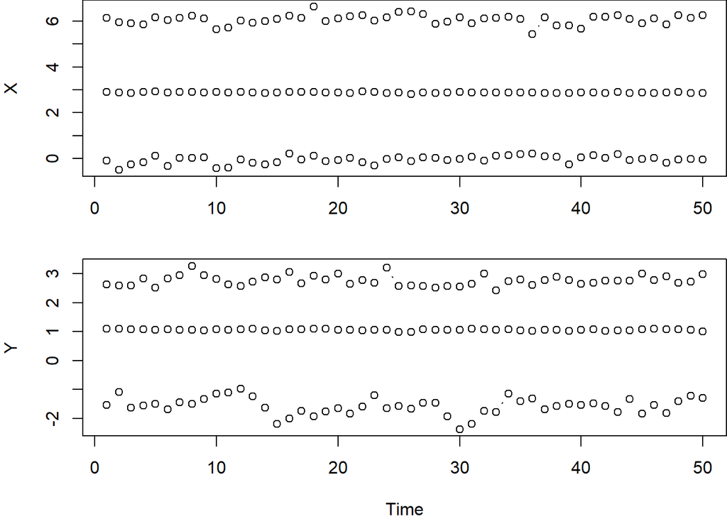

```r
phi_X = .2
phi_Y = .25
phi_XY = .05
beta_YX = 0.3

psi_X = .2
psi_Y = .25

gamma = c(3.0, 1.0)
var_gamma = c(1.8, 0.6)  # variances of parameter
# Construct the covariance matrix from the variances and a random correlation
# matrix drawn from a LKJ-distribution. Higher values for eta indicate that
# high correlations become more unlikely.
Omega = diag(sqrt(var_gamma)) %*% rlkjcorr(n=1,K=2,eta=100.0) %*% diag(sqrt(var_gamma))
# Omega = diag(var_gamma)
# random individual parameters
u = mvrnorm(N_subj, rep(0, 2), Sigma = Omega)


# Given those parameter values, we can now simulate a data set that reflects the model specification:
set.seed(2023)
# Prepare array to store the data in arrays of dimensions(N_subj, N_obs)
X = array(rep(0, N_subj * N_obs), c(N_subj, N_obs))
Y = array(rep(0, N_subj * N_obs), c(N_subj, N_obs))
for (i in 1:N_subj) {
  # calculate within-person parameters
  mu_X = u[i,1] + gamma[1]
  mu_Y = u[i,2] + gamma[2]
  # simulate data for one person
  subj_data <- simulate_within(mu_X, mu_Y, phi_X, phi_Y, phi_XY, beta_YX, psi_X, psi_Y, N_obs)
  # store simulations in result vector
  X[i,] = subj_data$X
  Y[i,] = subj_data$Y
}

data_summary_plot(X,Y)
```

```r
#For use in Stan, we compile all necessary data into a `list`:
data_list = list(
  N_obs = N_obs,
  N_subj = N_subj,
  X = X,
  Y = Y,
  N_mis_X = 0,
  N_mis_Y = 0,
  ii_mis_X = c(),
  ii_mis_Y = c()
)
```

Next, we can compile the model and fit the data. As this model family is a bit more complicated, fitting takes some time:

```r
model_1 <- cmdstan_model('stan/1_full.stan')
path_1 <- 'fits/model1'
dir.create(path_1, recursive = TRUE, showWarnings = FALSE)
file_path = file.path(paste0("data/data_list_", modelNr, ".rds"))
if (!file.exists(file_path)) {
  saveRDS(data_list, file_path)
}
```

```r
if (length(list.files(path_1, pattern = "chain")) > 0) { # here
  fit_1 <- as_cmdstan_fit(list.files(path_1, pattern = "chain", full.names = TRUE)) # here
} else {
# Run Stan Model
  fit_1 <- model_1$sample( # here
    data = data_list,
    chains=4,
    parallel_chains=4,
    refresh=100,
    iter_warmup = 1000,
    iter_sampling = 2000,
    save_warmup = TRUE,
    output_dir = path_1, # here
    output_basename = "chain"
  )
}
```

## 1.2 Mplus

For use in Mplus, `MplusAutomation` provides a data preparation function:

```r
path_mplus <- paste0("mplus/model_", modelNr)

if (length(list.files(path_mplus)) > 0) { # here
  print("already run")
} else {
  mplus <- data.frame(id = rep(1:N_subj, each = N_obs),
                      day = rep(1:N_obs, times = N_subj),
                      X = as.vector(t(X)),
                      Y = as.vector(t(Y)))

  mplus <- mplus[order(mplus$id),]

  dir.create(path_mplus, showWarnings = FALSE)
  mplus_txt <- prepareMplusData(mplus, paste0("mplus/model_", modelNr, "/mplus.dat"))

  # Mplus
  runModels(paste0(path_mplus, "/model_", modelNr, ".inp"))
}
```

```
[1] "already run"
```

## 1.3 Results

To assess whether fitting was successful, we consider two main measures. First, the $\widehat R$ values should be close to 1 (the most recent advice is a strict criterion of $\widehat R < 1.01$). Second, the proportion of divergent transitions, which in the best case should be zero. Divergences are zero unless otherwise reported here. In this case (and in the following 5), no divergences were found.

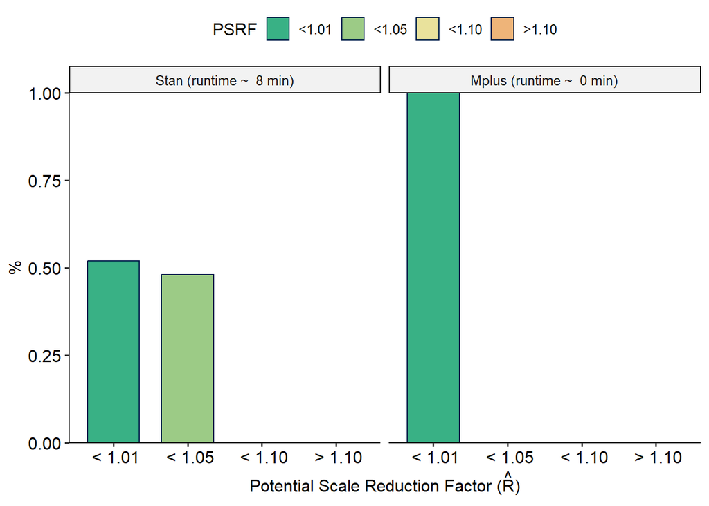

```r
# Plots - rhat
rhat_comp_F_MP(TRUE, mplusDraws = paste0(path_mplus, "/draws.dat"),
               mplusOut = paste0(path_mplus, "/model_", modelNr, ".out"),
               fit = fit_1) # here
```

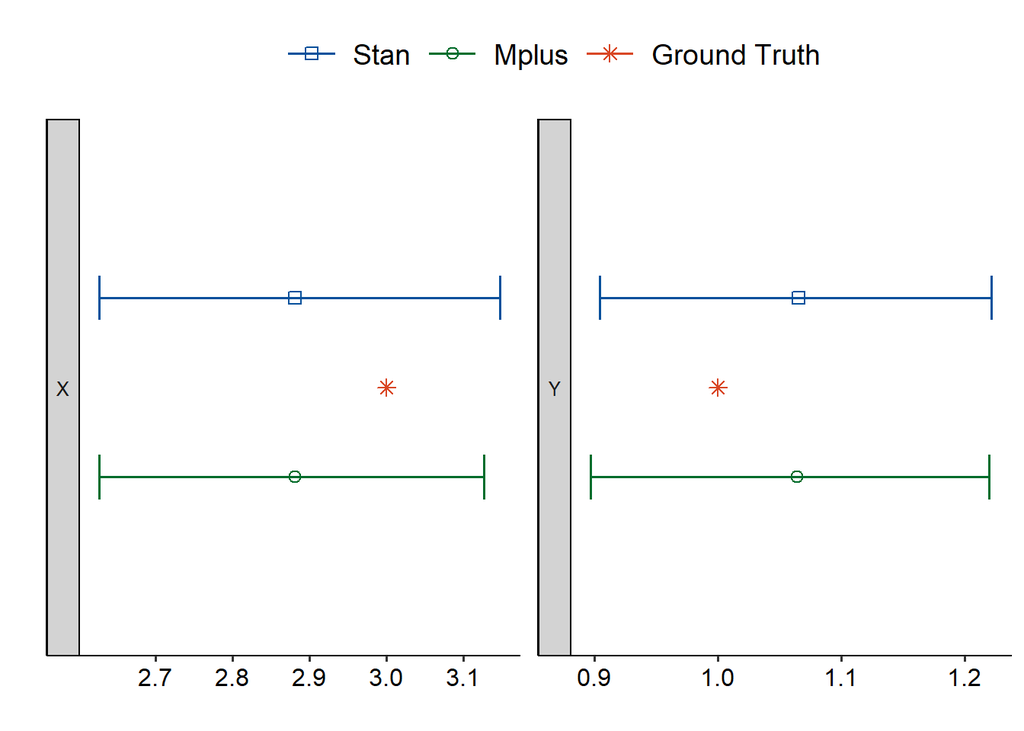

```r
# Plots - rhat
est_comp_F_MP(TRUE, mplusOut = paste0(path_mplus, "/model_", modelNr, ".out"),
               fit = fit_1) # here
```

# 2 Model 2

## 2.1 Simulating data

```r
modelNr = 2
modelName = "hamaker model 2"
```

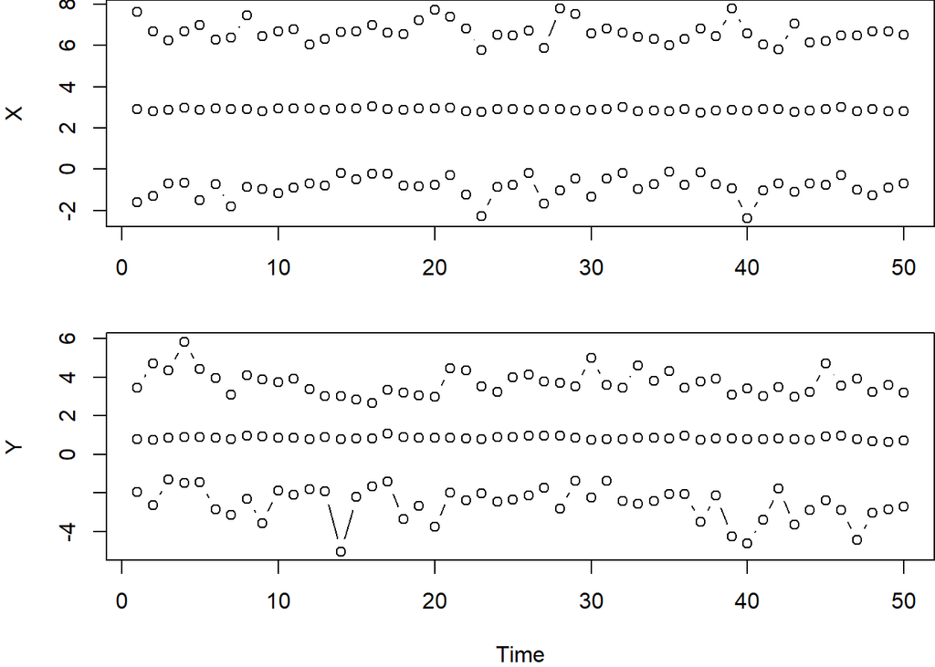

```r
mu_phi_X = .2
mu_phi_Y = .25
mu_phi_XY = .05
mu_beta_YX = 0.3

mu_log_psi_X_2 = -1.6
mu_log_psi_Y_2 = -1.4

mu_X = 3.0
mu_Y = 1.0

gamma = c(mu_X, mu_Y, mu_phi_X, mu_phi_Y, mu_phi_XY, mu_beta_YX, mu_log_psi_X_2, mu_log_psi_Y_2)
var_gamma = c(1.8, 0.6, .03, .03, .03, .05, 1, 1)  # variances of parameter
# Construct the covariance matrix from the variances and a random correlation
# matrix drawn from a LKJ-distribution. Higher values for eta indicate that
# high correlations become more unlikely.
Omega = diag(sqrt(var_gamma)) %*% rlkjcorr(n=1,K=length(gamma),eta=100.0) %*% diag(sqrt(var_gamma))
# Omega = diag(var_gamma)
# random individual parameters
u = mvrnorm(N_subj, rep(0, length(gamma)), Sigma = Omega)

# Prepare array to store the data in an array of dimensions(N_subj, N_obs, p),
# this can be passed to Stan as a (N_subj, N_obs)-matrix of p-dim. vectors.
X = array(rep(0, N_subj * N_obs), c(N_subj, N_obs))
Y = array(rep(0, N_subj * N_obs), c(N_subj, N_obs))
for (i in 1:N_subj) {
  mu_X = gamma[1] + u[i,1]
  mu_Y = gamma[2] + u[i,2]

  phi_X = gamma[3] + u[i,3]
  phi_Y = gamma[4] + u[i,4]
  phi_XY = gamma[5] + u[i,5]
  beta_YX = gamma[6] + u[i,6]

  psi_X = sqrt(exp(gamma[7] + u[i,7]))
  psi_Y = sqrt(exp(gamma[8] + u[i,8]))

  subj_data <- simulate_within(mu_X, mu_Y, phi_X, phi_Y, phi_XY, beta_YX, psi_X, psi_Y, N_obs)
  X[i,] = subj_data$X
  Y[i,] = subj_data$Y
}

# For certain some of parameters, the time series might diverge. We can check graphically if that occurred. If a divergent time series is present, we would see exploding minimum or maximum values for later time steps. As this doesn't occur in reality, it would indicate an invalid simulation. Here, the pattern looks reasonable, so we can use this simulated data set.
data_summary_plot(X,Y)
```

```r
#For use in Stan, we compile all necessary data into a `list`:
data_list = list(
  N_obs = N_obs,
  N_subj = N_subj,
  X = X,
  Y = Y,
  N_mis_X = 0,
  N_mis_Y = 0,
  ii_mis_X = c(),
  ii_mis_Y = c()
)
```

Next, we can compile the model and fit the data. As this model family is a bit more complicated, fitting takes some time:

```r
model_2 <- cmdstan_model('stan/2_full.stan')
path_2 <- 'fits/model2'
dir.create(path_2, recursive = TRUE, showWarnings = FALSE)
file_path = file.path(paste0("data/data_list_", modelNr, ".rds"))
if (!file.exists(file_path)) {
  saveRDS(data_list, file_path)
}
```

```r
if (length(list.files(path_2, pattern = "chain")) > 0) { # here
  fit_2 <- as_cmdstan_fit(list.files(path_2, pattern = "chain", full.names = TRUE)) # here
} else {
  # Run Stan Model
  fit_2 <- model_2$sample( # here
    data = data_list,
    chains=4,
    parallel_chains=4,
    refresh=100,
    iter_warmup = 1000,
    iter_sampling = 2000,
    save_warmup = TRUE,
    output_dir = path_2, # here
    output_basename = "chain"
  )
}
```

## 2.2 Mplus

For use in Mplus, `MplusAutomation` provides a data preparation function:

```r
path_mplus <- paste0("mplus/model_", modelNr)

if (length(list.files(path_mplus)) > 0) { # here
  print("already run")
} else {
  mplus <- data.frame(id = rep(1:N_subj, each = N_obs),
                      day = rep(1:N_obs, times = N_subj),
                      X = as.vector(t(X)),
                      Y = as.vector(t(Y)))

  mplus <- mplus[order(mplus$id),]

  dir.create(path_mplus, showWarnings = FALSE)
  mplus_txt <- prepareMplusData(mplus, paste0("mplus/model_", modelNr, "/mplus.dat"))

  # Mplus
  runModels(paste0(path_mplus, "/model_", modelNr, ".inp"))
}
```

```
[1] "already run"
```

## 2.3 Results

To assess whether fitting was successful, we consider two main measures. First, the $\widehat R$ values should be close to one (the most recent advice is a strict criterion of $\widehat R < 1.01$). Second, the proportion of divergent transitions, which in the best case should be zero.

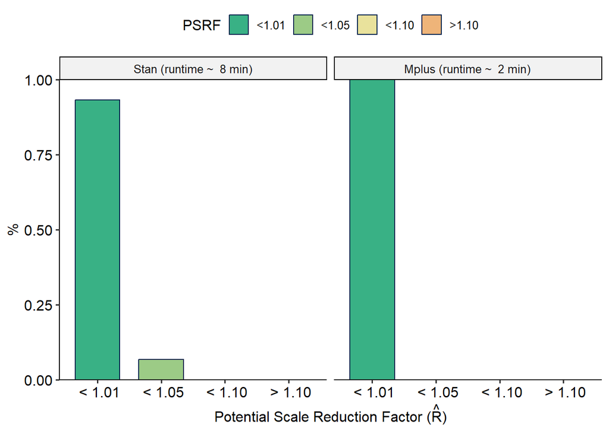

```r
# Plots - rhat
rhat_comp_F_MP(TRUE, mplusDraws = paste0(path_mplus, "/draws.dat"),
               mplusOut = paste0(path_mplus, "/model_", modelNr, ".out"),
               fit = fit_2) # here
```

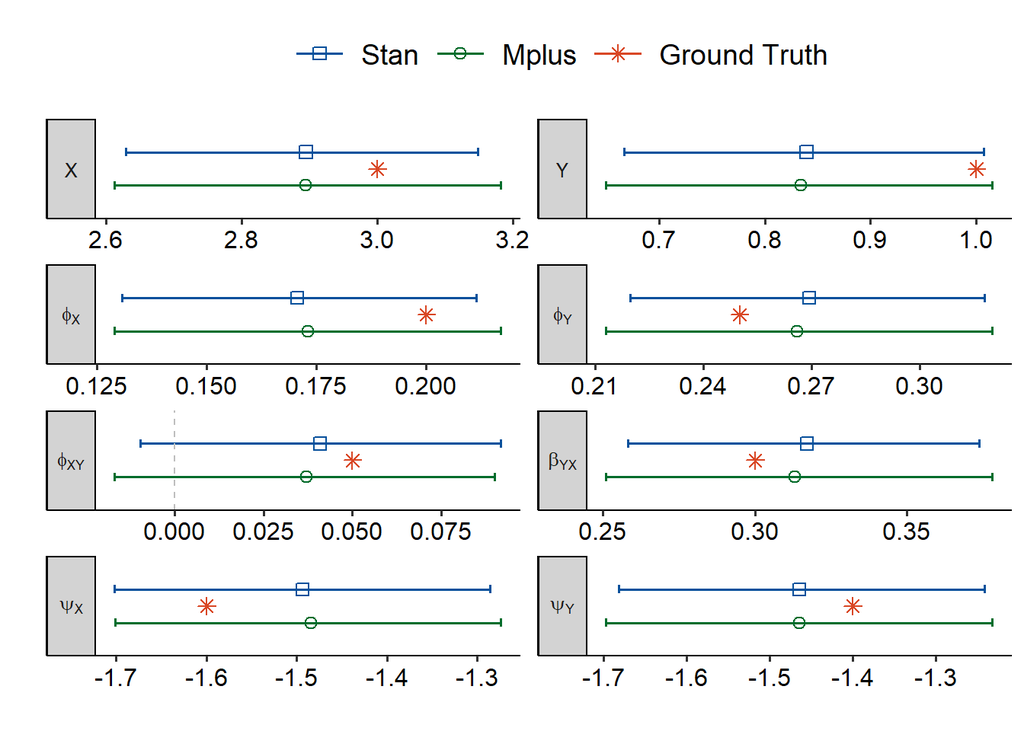

```r
# Plots - rhat
est_comp_F_MP(TRUE, mplusOut = paste0(path_mplus, "/model_", modelNr, ".out"),
               fit = fit_2) # here
```

# 3 Model 3

## 3.1 Simulating data

```r
modelNr = 3
modelName = "hamaker model 3"
set.seed(1)
```

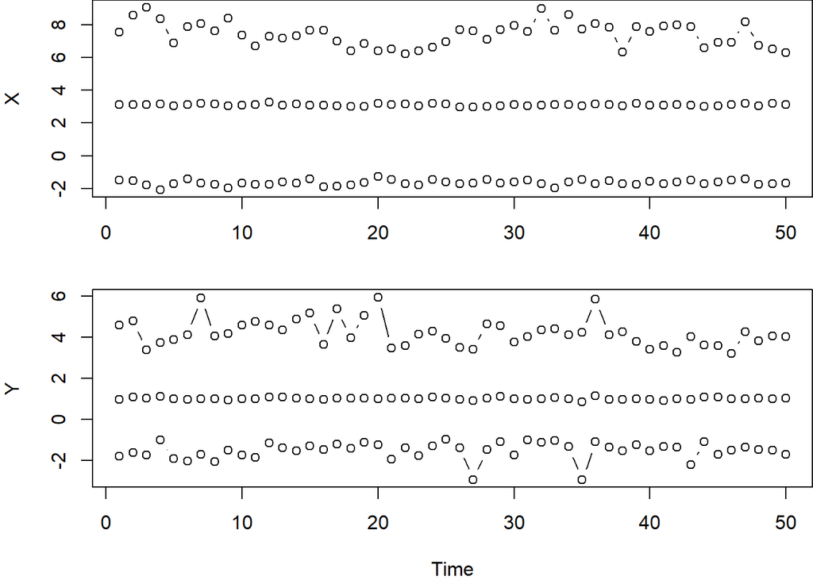

```r
mu_phi_X = .2
mu_phi_Y = .25
mu_phi_XY = .05
mu_beta_YX = 0.3

mu_log_psi_X_2 = -1.6
mu_log_psi_Y_2 = -1.4

mu_X = 3.0
mu_Y = 1.0

gamma = c(mu_X, mu_Y, mu_phi_X, mu_phi_Y, mu_phi_XY, mu_beta_YX, mu_log_psi_X_2, mu_log_psi_Y_2)
var_gamma = c(1.8, 0.6, .03, .03, .03, .05, 1, 1) / 1.8  # variances of parameter
# Construct the covariance matrix from the variances and a random correlation
# matrix drawn from a LKJ-distribution. Higher values for eta indicate that
# high correlations become more unlikely.
Omega = diag(var_gamma)
# Omega = diag(var_gamma)
# random individual parameters
u = mvrnorm(N_subj, rep(0, length(gamma)), Sigma = Omega)

a = c(1, 0.6, .05, .05, .05, .05, .4, .4)

P = rnorm(N_subj, 0, 1)

# Prepare array to store the data in an array of dimensions(N_subj, N_obs, p),
# this can be passed to Stan as a (N_subj, N_obs)-matrix of p-dim. vectors.
X = array(rep(0, N_subj * N_obs), c(N_subj, N_obs))
Y = array(rep(0, N_subj * N_obs), c(N_subj, N_obs))
for (i in 1:N_subj) {
  mu_X = gamma[1] + a[1] * P[i] + u[i,1]
  mu_Y = gamma[2] + a[2] * P[i] + u[i,2]

  phi_X = gamma[3] + a[3] * P[i] + u[i,3]
  phi_Y = gamma[4] + a[4] * P[i] + u[i,4]
  phi_XY = gamma[5] + a[5] * P[i] + u[i,5]
  beta_YX = gamma[6] + a[6] * P[i] + u[i,6]

  psi_X = sqrt(exp(gamma[7] + a[7] * P[i] + u[i,7]))
  psi_Y = sqrt(exp(gamma[8] + a[8] * P[i] + u[i,8]))

  data_within <- simulate_within(mu_X, mu_Y, phi_X, phi_Y, phi_XY, beta_YX, psi_X, psi_Y, N_obs)
  X[i,] = data_within$X
  Y[i,] = data_within$Y
}
# For certain some of parameters, the time series might diverge. We can check graphically if that occurred. If a divergent time series is present, we would see exploding minimum or maximum values for later time steps. As this doesn't occur in reality, it would indicate an invalid simulation. Here, the pattern looks reasonable, so we can use this simulated data set.
data_summary_plot(X,Y)
```

```r
#For use in Stan, we compile all necessary data into a `list`:
data_list = list(
  N_obs = N_obs,
  N_subj = N_subj,
  X = X,
  Y = Y,
  P = P,
  N_mis_X = 0,
  N_mis_Y = 0,
  ii_mis_X = c(),
  ii_mis_Y = c()
)
```

Next, we can compile the model and fit the data. As this model family is a bit more complicated, fitting takes some time:

```r
model_3 <- cmdstan_model('stan/3_full.stan')
path_3 <- 'fits/model3'
dir.create(path_3, recursive = TRUE, showWarnings = FALSE)
file_path = file.path(paste0("data/data_list_", modelNr, ".rds"))
if (!file.exists(file_path)) {
  saveRDS(data_list, file_path)
}
```

```r
if (length(list.files(path_3, pattern = "chain")) > 0) { # here
  fit_3 <- as_cmdstan_fit(list.files(path_3, pattern = "chain", full.names = TRUE)) # here
} else {
  # Run Stan Model
  fit_3 <- model_3$sample( # here
    data = data_list,
    chains=4,
    parallel_chains=4,
    refresh=100,
    iter_warmup = 1000,
    iter_sampling = 2000,
    save_warmup = TRUE,
    output_dir = path_3, # here
    output_basename = "chain"
  )
}
```

## 3.2 Mplus

For use in Mplus, `MplusAutomation` provides a data preparation function:

```r
path_mplus <- paste0("mplus/model_", modelNr)

if (length(list.files(path_mplus)) > 0) { # here
  print("already run")
} else {
  mplus <- data.frame(id = rep(1:N_subj, each = N_obs),
                      day = rep(1:N_obs, times = N_subj),
                      X = as.vector(t(X)),
                      Y = as.vector(t(Y)),
                      P = as.vector(rep(t(P), each = N_obs)))

  mplus <- mplus[order(mplus$id),]

  dir.create(path_mplus, showWarnings = FALSE)
  mplus_txt <- prepareMplusData(mplus, paste0("mplus/model_", modelNr, "/mplus.dat"))

  # Mplus
  runModels(paste0(path_mplus, "/model_", modelNr, ".inp"))
}
```

```
[1] "already run"
```

## 3.3 Results

To assess whether fitting was successful, we consider two main measures. First, the $\widehat R$ values should be close to one (the most recent advice is a strict criterion of $\widehat R < 1.01$). Second, the proportion of divergent transitions, which in the best case should be zero.

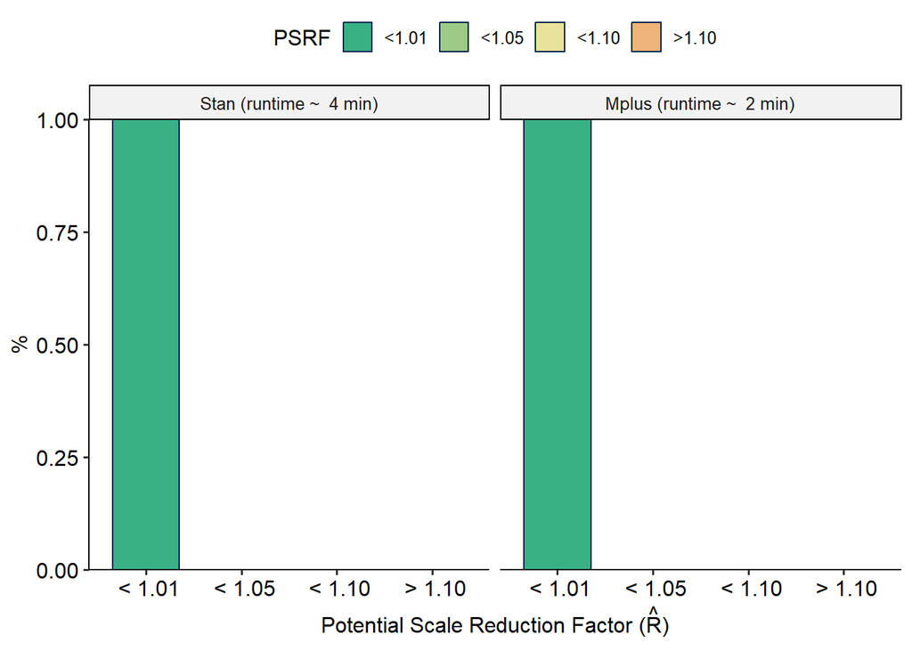

```r
# Plots - rhat
rhat_comp_F_MP(TRUE, mplusDraws = paste0(path_mplus, "/draws.dat"),
               mplusOut = paste0(path_mplus, "/model_", modelNr, ".out"),
               fit = fit_3) # here
```

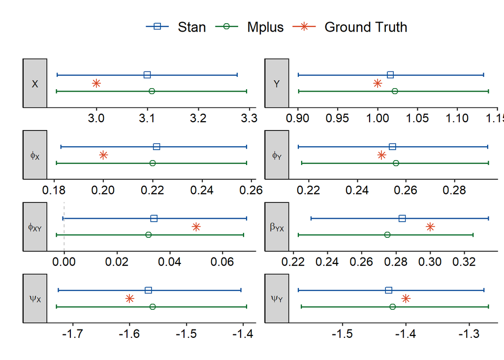

```r
# Plots - rhat
est_comp_F_MP(TRUE, mplusOut = paste0(path_mplus, "/model_", modelNr, ".out"),
               fit = fit_3) # here
```

# 4 Model 4

## 4.1 Simulating data

```r
modelNr = 4
modelName = "hamaker model 4"
```

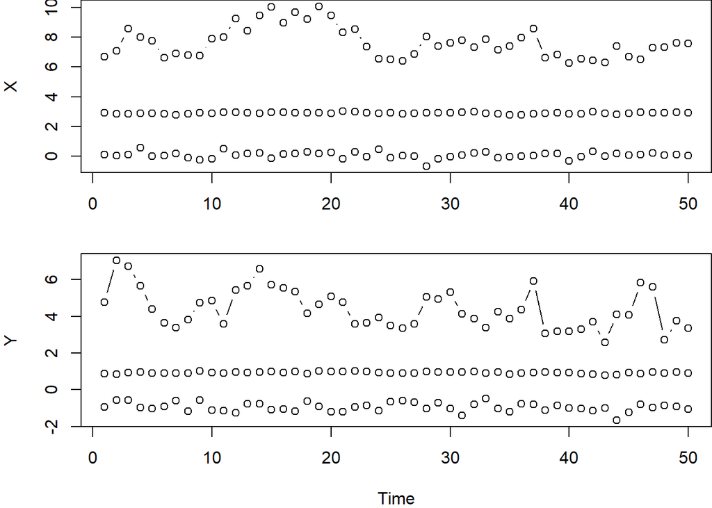

```r
mu_phi_X = .2
mu_phi_Y = .25
mu_phi_XY = .05
mu_beta_YX = 0.3

mu_log_psi_X_2 = -1.6
mu_log_psi_Y_2 = -1.4

mu_X = 3.0
mu_Y = 1.0

gamma = c(mu_X, mu_Y, mu_phi_X, mu_phi_Y, mu_phi_XY, mu_beta_YX, mu_log_psi_X_2, mu_log_psi_Y_2)
var_gamma = c(1.8, 0.6, .03, .03, .03, .05, 1, 1) / 5  # variances of parameter
# Construct the covariance matrix from the variances and a random correlation
# matrix drawn from a LKJ-distribution. Higher values for eta indicate that
# high correlations become more unlikely.
Omega = diag(var_gamma)
# Omega = diag(var_gamma)
# random individual parameters
u = mvrnorm(N_subj, rep(0, length(gamma)), Sigma = Omega)

f = c(1, 0.6, .05, .05, .05, .05, .4, .4)

C = rnorm(N_subj, 0, 1)

# Prepare array to store the data in an array of dimensions(N_subj, N_obs, p),
# this can be passed to Stan as a (N_subj, N_obs)-matrix of p-dim. vectors.
X = array(rep(0, N_subj * N_obs), c(N_subj, N_obs))
Y = array(rep(0, N_subj * N_obs), c(N_subj, N_obs))
for (i in 1:N_subj) {
  mu_X = gamma[1] + f[1] * C[i] + u[i,1]
  mu_Y = gamma[2] + f[2] * C[i] + u[i,2]

  phi_X = gamma[3] + f[3] * C[i] + u[i,3]
  phi_Y = gamma[4] + f[4] * C[i] + u[i,4]
  phi_XY = gamma[5] + f[5] * C[i] + u[i,5]
  beta_YX = gamma[6] + f[6] * C[i] + u[i,6]

  psi_X = sqrt(exp(gamma[7] + f[7] * C[i] + u[i,7]))
  psi_Y = sqrt(exp(gamma[8] + f[8] * C[i] + u[i,8]))

  data_within <- simulate_within(mu_X, mu_Y, phi_X, phi_Y, phi_XY, beta_YX, psi_X, psi_Y, N_obs)
  X[i,] = data_within$X
  Y[i,] = data_within$Y
}
# For certain some of parameters, the time series might diverge. We can check graphically if that occurred. If a divergent time series is present, we would see exploding minimum or maximum values for later time steps. As this doesn't occur in reality, it would indicate an invalid simulation. Here, the pattern looks reasonable, so we can use this simulated data set.
data_summary_plot(X,Y)
```

```r
#For use in Stan, we compile all necessary data into a `list`:
data_list = list(
  N_obs = N_obs,
  N_subj = N_subj,
  X = X,
  Y = Y,
  N_mis_X = 0,
  N_mis_Y = 0,
  ii_mis_X = c(),
  ii_mis_Y = c()
)
```

Next, we can compile the model and fit the data. As this model family is a bit more complicated, fitting takes some time:

```r
model_4 <- cmdstan_model('stan/4_full.stan')
path_4 <- 'fits/model4'
dir.create(path_4, recursive = TRUE, showWarnings = FALSE)
file_path = file.path(paste0("data/data_list_", modelNr, ".rds"))
if (!file.exists(file_path)) {
  saveRDS(data_list, file_path)
}
```

```r
if (length(list.files(path_4, pattern = "chain")) > 0) { # here
  fit_4 <- as_cmdstan_fit(list.files(path_4, pattern = "chain", full.names = TRUE)) # here
} else {
  # Run Stan Model
  fit_4 <- model_4$sample( # here
    data = data_list,
    chains=4,
    parallel_chains=4,
    refresh=100,
    iter_warmup = 1000,
    iter_sampling = 2000,
    save_warmup = TRUE,
    output_dir = path_4, # here
    output_basename = "chain"
  )
}
```

## 4.2 Mplus

For use in Mplus, `MplusAutomation` provides a data preparation function:

```r
path_mplus <- paste0("mplus/model_", modelNr)

if (length(list.files(path_mplus)) > 0) { # here
  print("already run")
} else {
  mplus <- data.frame(id = rep(1:N_subj, each = N_obs),
                      day = rep(1:N_obs, times = N_subj),
                      X = as.vector(t(X)),
                      Y = as.vector(t(Y)))

  mplus <- mplus[order(mplus$id),]

  dir.create(path_mplus, showWarnings = FALSE)
  mplus_txt <- prepareMplusData(mplus, paste0("mplus/model_", modelNr, "/mplus.dat"))

  # Mplus
  runModels(paste0(path_mplus, "/model_", modelNr, ".inp"))
}
```

```
[1] "already run"
```

## 4.3 Results

To assess whether fitting was successful, we consider two main measures. First, the $\widehat R$ values should be close to one (the most recent advice is a strict criterion of $\widehat R < 1.01$). Second, the proportion of divergent transitions, which in the best case should be zero.

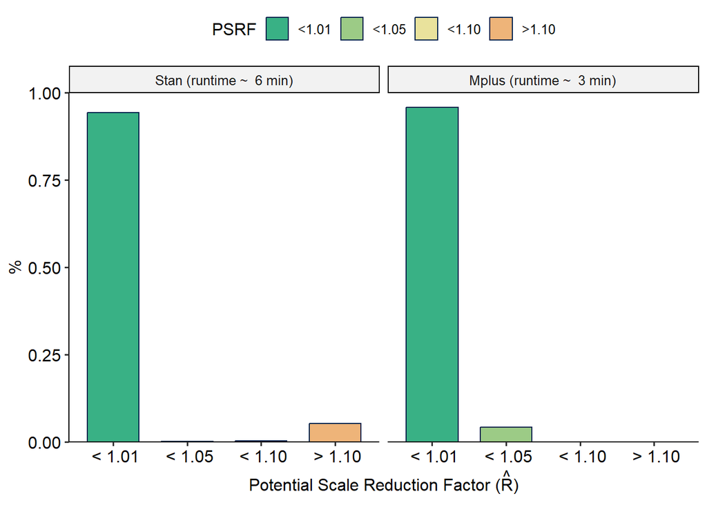

```r
# Plots - rhat
rhat_comp_F_MP(TRUE, mplusDraws = paste0(path_mplus, "/draws.dat"),
               mplusOut = paste0(path_mplus, "/model_", modelNr, ".out"),
               fit = fit_4) # here
```

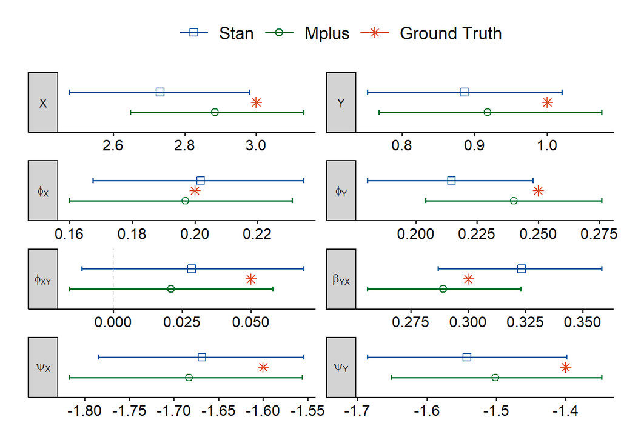

```r
# Plots - rhat
est_comp_F_MP(TRUE, mplusOut = paste0(path_mplus, "/model_", modelNr, ".out"),
               fit = fit_4) # here
```

# 5 Model 5

## 5.1 Simulating data

```r
modelNr = 5
modelName = "hamaker model 5"
```

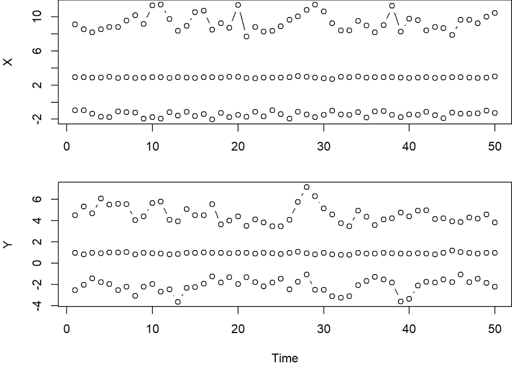

```r
mu_phi_X = .2
mu_phi_Y = .25
mu_phi_XY = .05
mu_beta_YX = 0.3

mu_log_psi_X_2 = -1.6
mu_log_psi_Y_2 = -1.4

mu_X = 3.0
mu_Y = 1.0

gamma = c(mu_X, mu_Y, mu_phi_X, mu_phi_Y, mu_phi_XY, mu_beta_YX, mu_log_psi_X_2, mu_log_psi_Y_2)
var_gamma = c(1.8, 0.6, .03, .03, .03, .05, 1, 1)  # variances of parameter
# Construct the covariance matrix from the variances and a random correlation
# matrix drawn from a LKJ-distribution. Higher values for eta indicate that
# high correlations become more unlikely.
Omega = diag(var_gamma)
# Omega = diag(var_gamma)
# random individual parameters
u = mvrnorm(N_subj, rep(0, length(gamma)), Sigma = Omega)

f = c(1, 0.6, .05, .05, .05, .05, .4, .4)
tau = rnorm(10, 0, 1)

sigma_P <- 1
sigma_O <- 1
P = rnorm(N_subj, 0, sigma_P)
O = rnorm(N_subj, 0, sigma_O)

# Prepare array to store the data in an array of dimensions(N_subj, N_obs, p),
# this can be passed to Stan as a (N_subj, N_obs)-matrix of p-dim. vectors.
X = array(rep(0, N_subj * N_obs), c(N_subj, N_obs))
Y = array(rep(0, N_subj * N_obs), c(N_subj, N_obs))
for (i in 1:N_subj) {
  mu_X = gamma[1] + f[1] * P[i] + u[i,1]
  mu_Y = gamma[2] + f[2] * P[i] + u[i,2]

  phi_X = gamma[3] + f[3] * P[i] + u[i,3]
  phi_Y = gamma[4] + f[4] * P[i] + u[i,4]
  phi_XY = gamma[5] + f[5] * P[i] + u[i,5]
  beta_YX = gamma[6] + f[6] * P[i] + u[i,6]

  psi_X = sqrt(exp(gamma[7] + f[7] * P[i] + u[i,7]))
  psi_Y = sqrt(exp(gamma[8] + f[8] * P[i] + u[i,8]))

  O[i] <- O[i] + tau[1] + tau[2] * P[i] + tau[3] * mu_X + tau[4] * mu_Y +
      tau[5] * phi_X + tau[6] * phi_Y + tau[7] * phi_XY +
      tau[8] * beta_YX + tau[9] * log(psi_X^2) + tau[10] * log(psi_Y^2)

  data_within <- simulate_within(mu_X, mu_Y, phi_X, phi_Y, phi_XY, beta_YX, psi_X, psi_Y, N_obs)
  X[i,] = data_within$X
  Y[i,] = data_within$Y
}
# For certain some of parameters, the time series might diverge. We can check graphically if that occurred. If a divergent time series is present, we would see exploding minimum or maximum values for later time steps. As this doesn't occur in reality, it would indicate an invalid simulation. Here, the pattern looks reasonable, so we can use this simulated data set.
data_summary_plot(X,Y)
```

```r
#For use in Stan, we compile all necessary data into a `list`:
data_list = list(
  N_obs = N_obs,
  N_subj = N_subj,
  X = X,
  Y = Y,
  P = P,
  O = O,
  N_mis_X = 0,
  N_mis_Y = 0,
  ii_mis_X = c(),
  ii_mis_Y = c()
)
```

Next, we can compile the model and fit the data. As this model family is a bit more complicated, fitting takes some time:

```r
model_5 <- cmdstan_model('stan/5_full.stan')
path_5 <- 'fits/model5'
dir.create(path_5, recursive = TRUE, showWarnings = FALSE)
file_path = file.path(paste0("data/data_list_", modelNr, ".rds"))
if (!file.exists(file_path)) {
  saveRDS(data_list, file_path)
}
```

```r
if (length(list.files(path_5, pattern = "chain")) > 0) { # here
  fit_5 <- as_cmdstan_fit(list.files(path_5, pattern = "chain", full.names = TRUE)) # here
} else {
  # Run Stan Model
  fit_5 <- model_5$sample( # here
    data = data_list,
    chains=4,
    parallel_chains=4,
    refresh=100,
    iter_warmup = 1000,
    iter_sampling = 2000,
    save_warmup = TRUE,
    output_dir = path_5, # here
    output_basename = "chain"
  )
}
```

## 5.2 Mplus

For use in Mplus, `MplusAutomation` provides a data preparation function:

```r
path_mplus <- paste0("mplus/model_", modelNr)

if (length(list.files(path_mplus)) > 0) { # here
  print("already run")
} else {
  mplus <- data.frame(id = rep(1:N_subj, each = N_obs),
                      day = rep(1:N_obs, times = N_subj),
                      X = as.vector(t(X)),
                      Y = as.vector(t(Y)),
                      P = as.vector(rep(t(P), each = N_obs)),
                      O = as.vector(rep(t(O), each = N_obs)))

  mplus <- mplus[order(mplus$id),]

  dir.create(path_mplus, showWarnings = FALSE)
  mplus_txt <- prepareMplusData(mplus, paste0("mplus/model_", modelNr, "/mplus.dat"))

  # Mplus
  runModels(paste0(path_mplus, "/model_", modelNr, ".inp"))
}
```

```
[1] "already run"
```

## 5.3 Results

To assess whether fitting was successful, we consider two main measures. First, the $\widehat R$ values should be close to one (the most recent advice is a strict criterion of $\widehat R < 1.01$). Second, the proportion of divergent transitions, which in the best case should be zero.

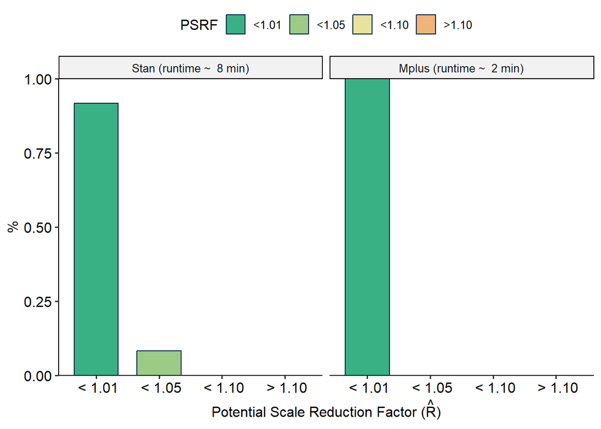

```r
# Plots - rhat
rhat_comp_F_MP(TRUE, mplusDraws = paste0(path_mplus, "/draws.dat"),
               mplusOut = paste0(path_mplus, "/model_", modelNr, ".out"),
               fit = fit_5) # here
```

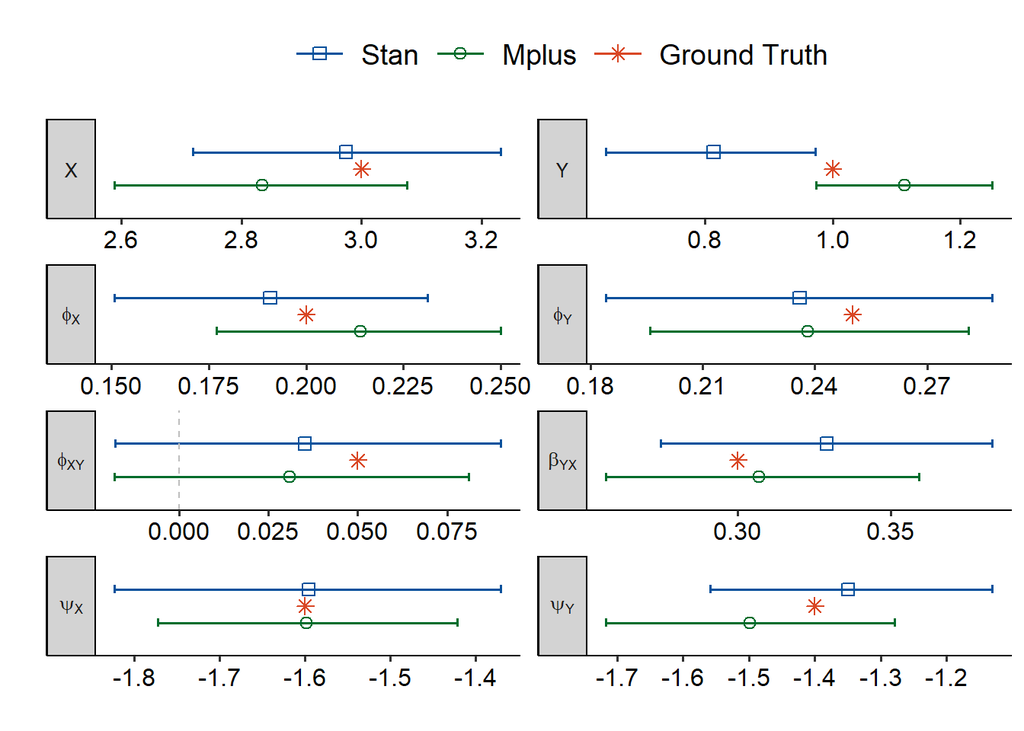

```r
# Plots - rhat
est_comp_F_MP(TRUE, mplusOut = paste0(path_mplus, "/model_", modelNr, ".out"),
               fit = fit_5) # here
```

# 6 Model 6

## 6.1 Simulating data

```r
modelNr = 6
modelName = "hamaker model 6"
```

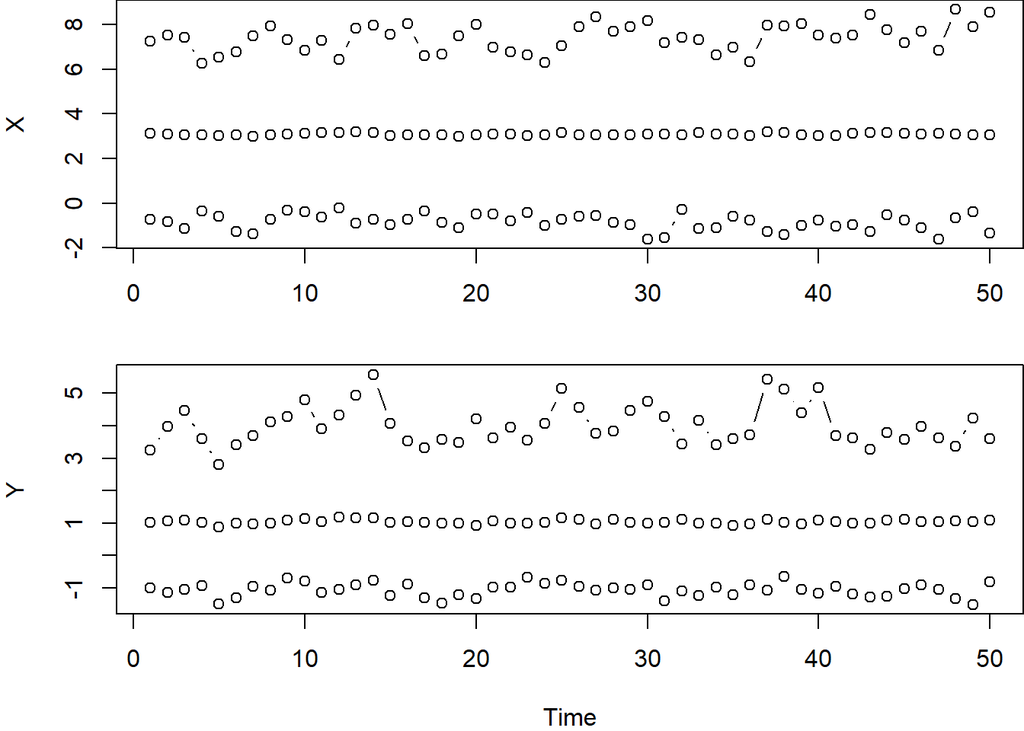

```r
mu_phi_X = .2
mu_phi_Y = .25
mu_phi_XY = .05
mu_beta_YX = 0.3

mu_log_psi_X_2 = -1.6
mu_log_psi_Y_2 = -1.4

mu_X = 3.0
mu_Y = 1.0

gamma = c(mu_X, mu_Y, mu_phi_X, mu_phi_Y, mu_phi_XY, mu_beta_YX, mu_log_psi_X_2, mu_log_psi_Y_2)
var_gamma = c(1.8, 0.6, .03, .03, .03, .05, 1, 1) / 5  # variances of parameter
# Construct the covariance matrix from the variances and a random correlation
# matrix drawn from a LKJ-distribution. Higher values for eta indicate that
# high correlations become more unlikely.
Omega = diag(var_gamma)
# Omega = diag(var_gamma)
# random individual parameters
u = mvrnorm(N_subj, rep(0, length(gamma)), Sigma = Omega)

f = c(1, 0.6, .05, .05, .05, .05, .4, .4)
tau <- rnorm(4, 0, 1)

P = rnorm(N_subj, 0, 1)
O = rnorm(N_subj, 0, .1)
C = rnorm(N_subj, 0, 1)

# Prepare array to store the data in an array of dimensions(N_subj, N_obs, p),
# this can be passed to Stan as a (N_subj, N_obs)-matrix of p-dim. vectors.
X = array(rep(0, N_subj * N_obs), c(N_subj, N_obs))
Y = array(rep(0, N_subj * N_obs), c(N_subj, N_obs))
for (i in 1:N_subj) {
  C[i] = C[i] + tau[4] * P[i]
  mu_X = gamma[1] + f[1] * C[i] + u[i,1]
  mu_Y = gamma[2] + f[2] * C[i] + u[i,2]

  phi_X = gamma[3] + f[3] * C[i] + u[i,3]
  phi_Y = gamma[4] + f[4] * C[i] + u[i,4]
  phi_XY = gamma[5] + f[5] * C[i] + u[i,5]
  beta_YX = gamma[6] + f[6] * C[i] + u[i,6]

  psi_X = sqrt(exp(gamma[7] + f[7] * C[i] + u[i,7]))
  psi_Y = sqrt(exp(gamma[8] + f[8] * C[i] + u[i,8]))

  data_within <- simulate_within(mu_X, mu_Y, phi_X, phi_Y, phi_XY, beta_YX, psi_X, psi_Y, N_obs)
  X[i,] = data_within$X
  Y[i,] = data_within$Y
  O[i] = O[i] + tau[1] + tau[2] * P[i] + tau[3] * C[i]
}
# For certain some of parameters, the time series might diverge. We can check graphically if that occurred. If a divergent time series is present, we would see exploding minimum or maximum values for later time steps. As this doesn't occur in reality, it would indicate an invalid simulation. Here, the pattern looks reasonable, so we can use this simulated data set.
data_summary_plot(X,Y)
```

```r
#For use in Stan, we compile all necessary data into a `list`:
data_list = list(
  N_obs = N_obs,
  N_subj = N_subj,
  X = X,
  Y = Y,
  P = P,
  O = O,
  N_mis_X = 0,
  N_mis_Y = 0,
  ii_mis_X = c(),
  ii_mis_Y = c()
)
```

Next, we can compile the model and fit the data. As this model family is a bit more complicated, fitting takes some time:

```r
model_6 <- cmdstan_model('stan/6_full.stan')
path_6 <- 'fits/model6'
dir.create(path_6, recursive = TRUE, showWarnings = FALSE)
file_path = file.path(paste0("data/data_list_", modelNr, ".rds"))
if (!file.exists(file_path)) {
  saveRDS(data_list, file_path)
}
```

```r
if (length(list.files(path_6, pattern = "chain")) > 0) { # here
  fit_6 <- as_cmdstan_fit(list.files(path_6, pattern = "chain", full.names = TRUE)) # here
} else {
  # Run Stan Model
  fit_6 <- model_6$sample( # here
    data = data_list,
    chains=4,
    parallel_chains=4,
    refresh=100,
    iter_warmup = 1000,
    iter_sampling = 3000,
    save_warmup = TRUE,
    output_dir = path_6, # here
    output_basename = "chain"
  )
}
```

## 6.2 Mplus

For use in Mplus, `MplusAutomation` provides a data preparation function:

```r
path_mplus <- paste0("mplus/model_", modelNr)

if (length(list.files(path_mplus)) > 0) { # here
  print("already run")
} else {
  mplus <- data.frame(id = rep(1:N_subj, each = N_obs),
                      day = rep(1:N_obs, times = N_subj),
                      X = as.vector(t(X)),
                      Y = as.vector(t(Y)),
                      P = as.vector(rep(t(P), each = N_obs)),
                      O = as.vector(rep(t(O), each = N_obs)))

  mplus <- mplus[order(mplus$id),]

  dir.create(path_mplus, showWarnings = FALSE)
  mplus_txt <- prepareMplusData(mplus, paste0("mplus/model_", modelNr, "/mplus.dat"))

  # Mplus
  runModels(paste0(path_mplus, "/model_", modelNr, ".inp"))
}
```

```
[1] "already run"
```

## 6.3 Results

To assess whether fitting was successful, we consider two main measures. First, the $\widehat R$ values should be close to one (the most recent advice is a strict criterion of $\widehat R < 1.01$). Second, the proportion of divergent transitions, which in the best case should be zero.

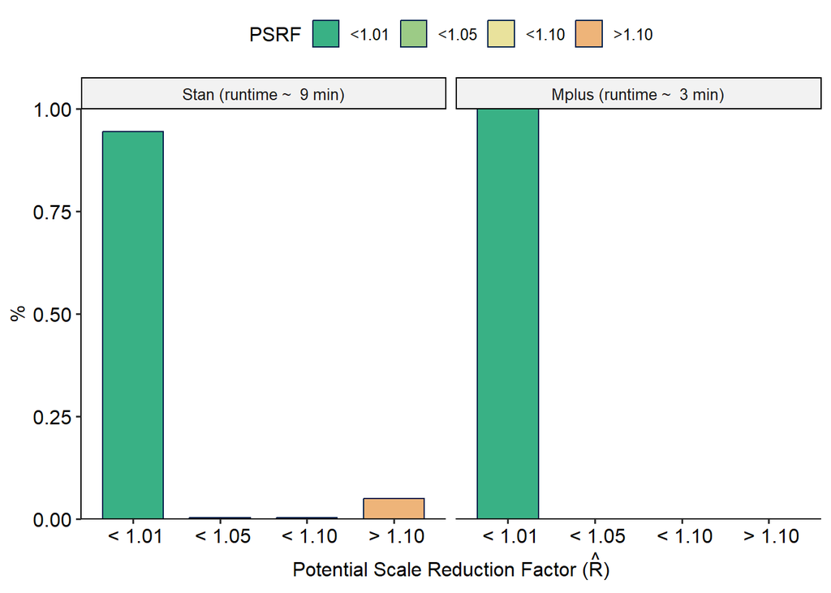

```r
# Plots - rhat
rhat_comp_F_MP(TRUE, mplusDraws = paste0(path_mplus, "/draws.dat"),
               mplusOut = paste0(path_mplus, "/model_", modelNr, ".out"),
               fit = fit_6) # here
```

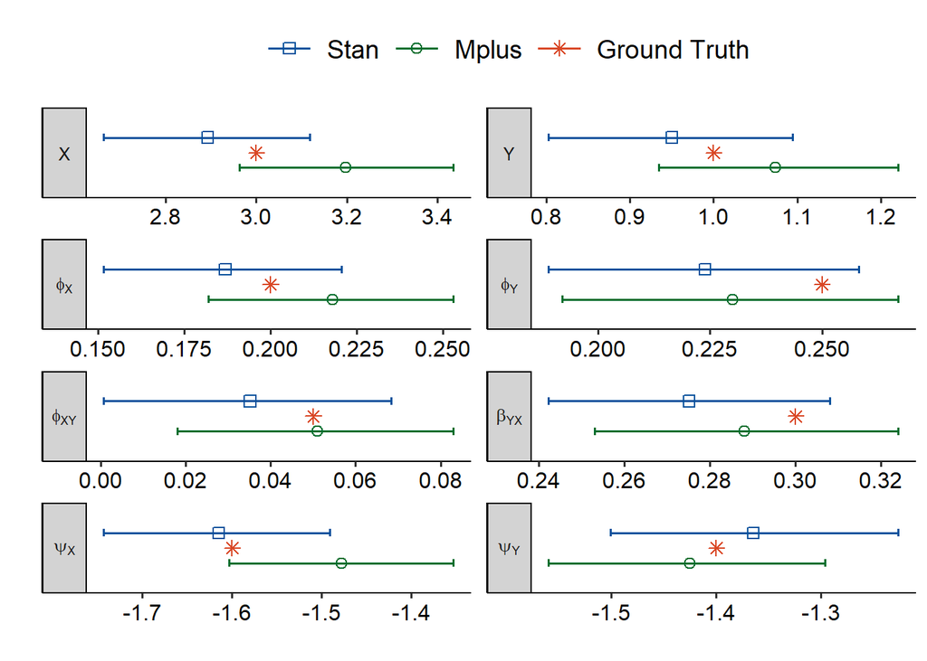

```r
# Plots - rhat
est_comp_F_MP(TRUE, mplusOut = paste0(path_mplus, "/model_", modelNr, ".out"),
               fit = fit_6) # here
```

# 7 Short discussion

Regarding parameter recovery, the comparison between Stan and Mplus for the simpler models (1, 2, and 3) shows negligible discrepancies. However, the more complex models (4, 5, and 6) exhibit greater variance in results between the two methods. This divergence does not currently raise substantial concerns but warrants attention. This variance may be attributed to the inherent instability in Dynamic Structural Equation Modeling (DSEM), as discussed by Baral & Curran (2023) in their article “Dynamic Structural Equation Models: Promising Yet Concerning” [available here](https://ajuronline.org/uploads/Volume_20_3/AJUR_Vol_20_Issue_3_Dec_2023_p69.pdf). A comprehensive analysis and discussion of these findings will be included in our forthcoming tutorial paper. But also see the supplementary .html file provided in this repository.